# Preprocesamiento de Datos Modelo de Clasificación Prevención de Fraude

Ing. Juan Sebastián Arboleda

21 de octubre de 2021

# Lectura de datos

```r
library(readr)
Fraud_Dataset_Data_ <- read_csv("Fraud Dataset  - Data .csv",
    col_types = cols(Fraude = col_integer()),
    locale = locale())

Data <- Fraud_Dataset_Data_
```

# Exploración de los datos

```r
# Dimensión
dim(Data)
```

```
## [1] 16880    21
```

```r
# Resumen de los datos
summary(Data)
```

```
##        A                 B                C                D
##  Min.   : 0.0000   Min.   :-1.000   Min.   :     0   Min.   :  0.0000
##  1st Qu.: 0.0000   1st Qu.: 4.000   1st Qu.:  1172   1st Qu.:  0.0000
##  Median : 0.0000   Median : 7.000   Median :  6173   Median :  0.0000
##  Mean   : 0.3092   Mean   : 7.645   Mean   : 39235   Mean   :  0.1987
##  3rd Qu.: 0.0000   3rd Qu.:11.000   3rd Qu.: 26889   3rd Qu.:  0.0000
##  Max.   :30.0000   Max.   :20.000   Max.   :617324   Max.   :180.0000
##                                     NA's   :3197
##        E                 F                 G                H
##  Min.   : 0.0000   Min.   :0.00000   Min.   :0.0000   Min.   : 0.0000
##  1st Qu.: 0.0000   1st Qu.:0.00000   1st Qu.:0.0000   1st Qu.: 0.0000
##  Median : 0.0000   Median :0.00000   Median :0.0000   Median : 0.0000
##  Mean   : 0.4337   Mean   :0.01588   Mean   :0.0052   Mean   : 0.0503
##  3rd Qu.: 0.0000   3rd Qu.:0.00000   3rd Qu.:0.0000   3rd Qu.: 0.0000
##  Max.   :45.0000   Max.   :1.00000   Max.   :1.0000   Max.   :21.0000
##
##        I                J                   K               L
##  Min.   : 0.0000   Length:16880       Min.   :0.120   Min.   :0.0000
##  1st Qu.: 0.0000   Class :character   1st Qu.:0.580   1st Qu.:0.0000
##  Median : 0.0000   Mode  :character   Median :0.680   Median :0.0000
##  Mean   : 0.1441                      Mean   :0.682   Mean   :0.4323
##  3rd Qu.: 0.0000                      3rd Qu.:0.800   3rd Qu.:1.0000
##  Max.   :24.0000                      Max.   :0.990   Max.   :7.0000
##                                       NA's   :12864
##        M                N                O                  P
##  Min.   : 1.000   Min.   : 1.000   Min.   :0.000000   Min.   : 1.000
##  1st Qu.: 1.000   1st Qu.: 1.000   1st Qu.:0.000000   1st Qu.: 1.000
##  Median : 1.000   Median : 1.000   Median :0.000000   Median : 1.000
##  Mean   : 1.544   Mean   : 1.092   Mean   :0.009419   Mean   : 1.631
##  3rd Qu.: 2.000   3rd Qu.: 1.000   3rd Qu.:0.000000   3rd Qu.: 2.000
##  Max.   :13.000   Max.   :10.000   Max.   :3.000000   Max.   :41.000
##
##        Q                  R                  S             Monto
##  Min.   :   0.000   Min.   :   0.000   Min.   :-1.00   Min.   :    0.05
##  1st Qu.:   0.000   1st Qu.:   0.000   1st Qu.: 9.56   1st Qu.:   33.81
##  Median :   0.000   Median :   0.000   Median :20.64   Median :   81.64
##  Mean   :   8.445   Mean   :   1.995   Mean   :29.13   Mean   :  161.84
##  3rd Qu.:   0.000   3rd Qu.:   0.000   3rd Qu.:39.21   3rd Qu.:  193.44
##  Max.   :2274.670   Max.   :2025.720   Max.   :99.97   Max.   :12538.44
##
##      Fraude
##  Min.   :0.0000
##  1st Qu.:0.0000
##  Median :0.0000
##  Mean   :0.2732
##  3rd Qu.:1.0000
##  Max.   :1.0000
##
```

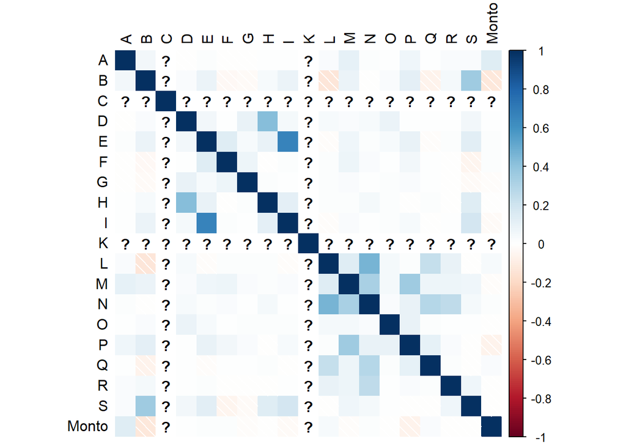

```r
library(corrplot)
library(dplyr)
#Un valor menor que 0 indica que existe una correlación negativa
#Un valor mayor que 0 indica que existe una correlación positiva
#una correlación de 0, o próxima a 0, indica que no hay relación lineal entre las dos variables

Data_num <- select(Data,-J, -Fraude)
corrplot(cor(Data_num),        # Matriz de correlación
         method = "shade", # Método para el gráfico de correlación
         type = "full",    # Estilo del gráfico (también "upper" y "lower")
         diag = TRUE,      # Si TRUE (por defecto), añade la diagonal
         tl.col = "black", # Color de las etiquetas
         bg = "white",     # Color de fondo
         title = "",       # Título
         col = NULL)       # Paleta de colores
```

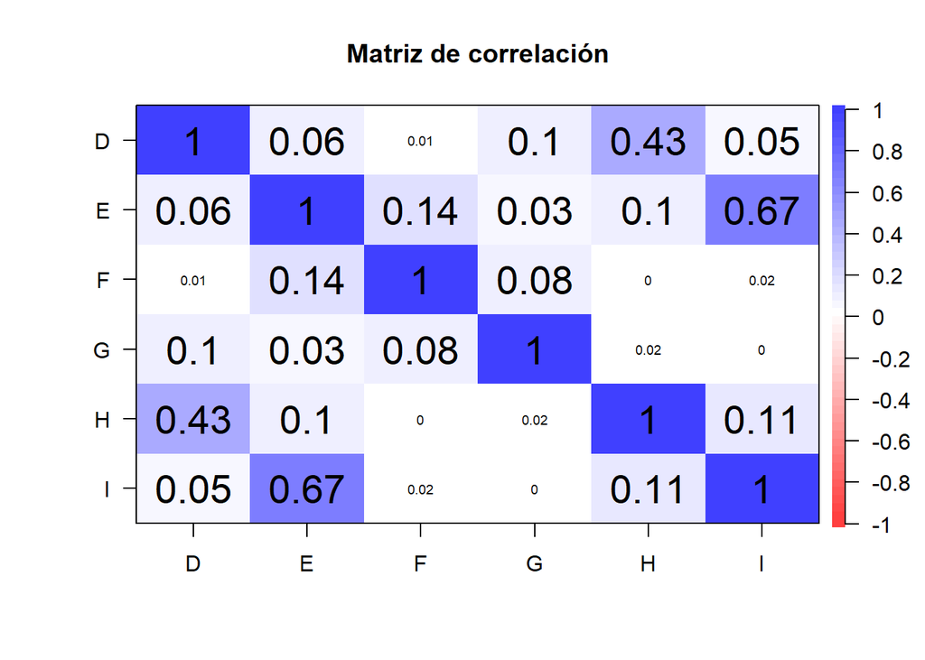

```r
#correlacion
library(psych)

corPlot(Data_num[ ,4:9], cex = 1.2, main = "Matriz de correlación")
```

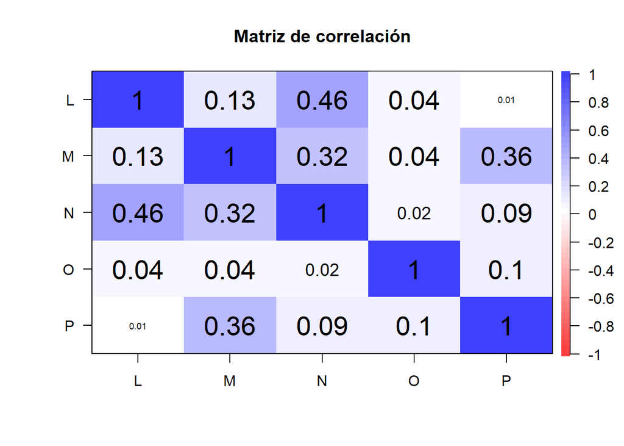

```r
corPlot(Data_num[ ,11:15], cex = 1.2, main = "Matriz de correlación")
```

```r
# Cantidad de registros con información del tipo NA
sum(is.na(Data))
```

```
## [1] 16061
```

```r
# Identificamos en que columna estan los datos faltantes
apply(X = is.na(Data), MARGIN = 2, FUN = sum)
```

```
##      A      B      C      D      E      F      G      H      I      J      K
##      0      0   3197      0      0      0      0      0      0      0  12864
##      L      M      N      O      P      Q      R      S  Monto Fraude
##      0      0      0      0      0      0      0      0      0      0
```

```r
# Identificamos en que columna estan los datos faltantes
summary(Data$C)
```

```
##    Min. 1st Qu.  Median    Mean 3rd Qu.    Max.    NA's
##       0    1172    6173   39235   26889  617324    3197
```

```r
summary(Data$K)
```

```
##    Min. 1st Qu.  Median    Mean 3rd Qu.    Max.    NA's
##   0.120   0.580   0.680   0.682   0.800   0.990   12864
```

# Preprocesamiento de los datos

Dado que en la fase de exploración identifiqué la presencia de registros del tipo NA en las variables C y K, procedo a realizar algunas transformaciones buscando mejorar la calidad de los mismos. Para el caso de la Variable C, en donde la presencia de faltantes no supera el 20% de los datos, vamos a completar esos faltantes con el valor del segundo quartil (la mediana). El valor promedio tambien es utilizado para ello, pero en este caso no es el mas acertado dado que la diferencia entre el tercer y cuarto quartil es muy amplia, lo que indica valores muy extremos que pueden afectar el valor promedio.

```r
Data$C <- ifelse(is.na(Data$C), median(Data$C, na.rm = TRUE), Data$C)
summary(Data$C)
```

```
##    Min. 1st Qu.  Median    Mean 3rd Qu.    Max.
##       0    1920    6173   32974   18570  617324
```

Para el caso de la variable K, en donde la cantidad de datos faltantes supera el 75% de sus datos, opté por no tener en cuenta esa variable en el análisis, dado que no aportaria confiabilidad.

```r
require(dplyr)
Data <- select(Data, -K)
Data
```

```
## # A tibble: 16,880 x 20
##        A     B     C     D     E     F     G     H     I J         L     M     N
##    <dbl> <dbl> <dbl> <dbl> <dbl> <dbl> <dbl> <dbl> <dbl> <chr> <dbl> <dbl> <dbl>
##  1     0    10 50257     0     0     0     0     0     0 UY        0     3     1
##  2     0    10 29014     0     0     0     0     0     0 UY        0     1     1
##  3     0     7    92     0     1     0     0     0     1 UY        0     3     1
##  4     9    16 50269     0     0     0     0     0     0 UY        0     3     1
##  5     0     8  8180     0     0     0     0     0     0 UY        0     1     1
##  6     1    12  1141     0     0     0     0     0     0 UY        0     1     1
##  7    10    18  4560     0     0     0     0     0     0 UY        0     3     1
##  8     0    10    38     0     0     0     0     0     0 UY        0     1     1
##  9     0    14  3790     0     0     0     0     0     0 UY        0     1     1
## 10     0    16 23210     0     0     0     0     0     0 UY        1     1     1
## # ... with 16,870 more rows, and 7 more variables: O <dbl>, P <dbl>, Q <dbl>,
## #   R <dbl>, S <dbl>, Monto <dbl>, Fraude <int>
```

Continuando con el analisis, veo que la columna J es la única del tipo categórico y asumo hace referencia al país.

```r
table(Data$J)
```

```
##
##   AR   AU   BR   CA   CH   CL   CO   ES   FR   GB   GT   IT   KR   MX   PT   TR
## 9329    1 4428   12    1    1    1  314    2    8    2    1    1 2366    1    1
##   UA   US   UY
##    1  230  180
```

La gran mayoria de los datos estan agrupados en solo 3 países, el resto suman una particpacion menor al 5%, por ello veo conveniente agruparlos en una sola categoria.

```r
#Data$J [Data$J== c ("AU","CA","CH")] <- "Otros"
#Data$J <- ifelse(Data$J == c("AU","CA","CH","CL","CO","ES","FR","GB","GT","IT","KR","PT","TR","UA","US","UY"), "Otros",Data$J)
Otros = c ("AR","BR","MX")
Data$J <- ifelse(Data$J %in% Otros, Data$J,"Otros")
table(Data$J)
```

```
##
##    AR    BR    MX Otros
##  9329  4428  2366   757
```

Buscando un formato mas amigable para los algoritmos, implemento la codificación one-hot encoding, de esta manera todas las variables quedaran bajo un formato numérico. Por último elimino la columna J original y escribo el archivo de salida con la data procesada que será modelada en python.

```r
library(fastDummies)
Data <- dummy_cols(Data, select_columns = c("J"))
Data <- select(Data, -J)
```

```r
write.csv(Data, "Data_Limpia.csv",sep = ",",dec = ".",fileEncoding = "UTF-8")
```